# Inference Project

## Question 1

Here’s the simulation code.

```r
lambda=.2
m=1000
n=40
means=numeric(m)
set.seed(1)
for (i in 1:m){
means[i]=mean(rexp(n,lambda))
}
```

### Compare Theoretical and Simulation Means

```r
median(means)
```

```
## [1] 4.95
```

### Compare variance:

The simulation variance is calculated:

```r
var(means)
```

```
## [1] 0.6111
```

### Show distribution is relatively normal:

I plot the histogram of the simulation and create a normal distribution that should theoretically match with the histogram. We see that the simulation matches theory well.

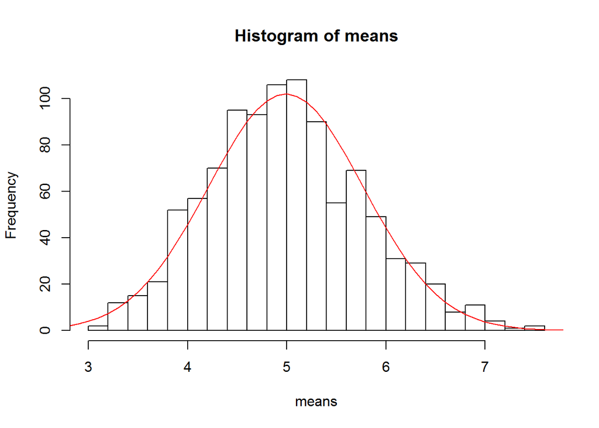

```r
x=seq(2,8,.1)
hist(means,20)
lines(x,1000/5*dnorm(x,mean=mean(means),sd=sd(means)),col="red")
```

### coverage of confidence interval

We look at the confidence interval:

```r
range=c(-1,1)*1.96*(1/lambda)/sqrt(n)+mean(means)
coverage=sum(means>=range[1] & means<=range[2])
coverage/m*100
```

```
## [1] 94.9
```

Notice that the coverage matches the theoretical coverage of 95% well.

## Problem 2:

Let’s load the data first.

```r
data(ToothGrowth)
data=ToothGrowth
```

### Exploratory Analysis:

Below, is a histogram of lengths for various dosages and supplements.

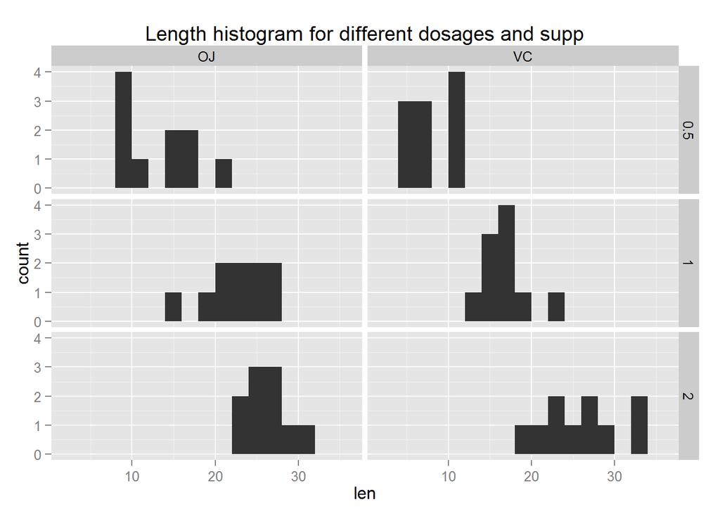

```r
library(ggplot2)
ggplot(data,aes(x=len))+geom_histogram(binwidth=2)+facet_grid(dose~supp)+ggtitle("Length histogram for different dosages and supp")
```

Below, we see the means of the data for various dosages and supplements.

```r
tapply(data$len,list(data$supp,data$dose),mean)
```

```
##      0.5     1     2
## OJ 13.23 22.70 26.06
## VC  7.98 16.77 26.14
```

From the exploratory analysis, we see that length tends to increase with dosage, and OJ seems to have a larger effect than VC.

### Summary of data

```r
summary(data)
```

```
##       len       supp         dose
##  Min.   : 4.2   OJ:30   Min.   :0.50
##  1st Qu.:13.1   VC:30   1st Qu.:0.50
##  Median :19.2           Median :1.00
##  Mean   :18.8           Mean   :1.17
##  3rd Qu.:25.3           3rd Qu.:2.00
##  Max.   :33.9           Max.   :2.00
```

We see taht there are 2 types of supplements, with 30 data points each. W also see taht the mean length is around 19. Also, dose ranges from .5 to 2.

### OJ versus VC Inference Analysis:

We will look at OJ versus VC for each dose: .5,1, and 2. We will calculate the two-tail p-value and 95% 2-tail confidence interval for each dose.

```r
OJ=subset(data$len,data$supp=="OJ"&data$dose==.5)
VC=subset(data$len,data$supp=="VC"&data$dose==.5)
p_val.5=t.test(OJ,VC,var.equal=FALSE)$p.value
conf.int.5=t.test(OJ,VC,var.equal=FALSE)$conf.int
p_val.5
```

```
## [1] 0.006359
```

```r
conf.int.5
```

```
## [1] 1.719 8.781
## attr(,"conf.level")
## [1] 0.95
```

```r
OJ=subset(data$len,data$supp=="OJ"&data$dose==1)
VC=subset(data$len,data$supp=="VC"&data$dose==1)
p_val1=t.test(OJ,VC,var.equal=FALSE)$p.value
conf.int1=t.test(OJ,VC,var.equal=FALSE)$conf.int
p_val1
```

```
## [1] 0.001038
```

```r
conf.int1
```

```
## [1] 2.802 9.058
## attr(,"conf.level")
## [1] 0.95
```

```r
OJ=subset(data$len,data$supp=="OJ"&data$dose==2)
VC=subset(data$len,data$supp=="VC"&data$dose==2)
p_val2=t.test(OJ,VC,var.equal=FALSE)$p.value
conf.int2=t.test(OJ,VC,var.equal=FALSE)$conf.int
p_val2
```

```
## [1] 0.9639
```

```r
conf.int2
```

```
## [1] -3.798  3.638
## attr(,"conf.level")
## [1] 0.95
```

## Results and Analysis:

Given alpha=.05 for a two-tailed p value test, we see that OJ increases length more than VC for both .5 and 1 dosages. For dose 2, we accept the null hypothesis. We see that the 95% confidence intervals also confirm this in that the intervals for .5 and 1 doses are completely positive whereas dose 2 ranges from negative to positive values. We can also account for the multiple hypothesis tests by multiplying each p-value by 3, but this would still have the first 2 p-values within our alpha limit, so it doesn’t change our results.